# Grafikus ábrázolások

Kurzus: Programozás I. 6. óra

Oktató: Balogh Kitti kttblgh@gmail.com

Időpont: 2017-03-21

## Vázlat

- `base` és `ggplot2`
- Adatok előkészítése a vizualizációkhoz
  - Data frame átalakítása `reshape2`-vel
- Oszlopdiagramok (Bar Graphs)
  - Egyszerű oszlopdiagramok - érték ábrázolása
  - Egyszerű oszlopdiagramok - gyakoriság ábrázolása
  - Csoportosított oszlopdiagramok (Stacked bar graphs)
- Vonaldiagramok (Line Graphs)
  - Egyszerű vonaldiagramok
  - Többszörös vonaldiagramok
- Pontfelhődiagramok/szórásdiagramok (Scatter Plots)
  - Egyszerű szórásdiagramok
  - Csoportra bontott szórásdiagramok
  - Annotált szórásdiagramok
  - Szórásdiagram mátrix
- Eloszlások ábrázolása
  - Hisztogramok és sűrűségfüggvények
  - Box plotok
- Plotok kimentése
- Irodalom

## `base` és `ggplot2`

- az R alapjáraton tartalmaz ábrázolásra használható függvényeket és emellett van egy nagyon kedvelt package, a `ggplot2`, ami kifejezetten vizualizációs célú
- hogy melyik használata a jobb, egyrészt célfüggő, másrészt attól is függ, hogy ki mit szokott meg:
  - [Flowing Data bejegyzés `ggplot2` vs `base` témában](http://flowingdata.com/2016/03/22/comparing-ggplot2-and-r-base-graphics/)
  - [Variance Explained bejegyzés `ggplot2` vs `base` témában](http://varianceexplained.org/r/why-I-use-ggplot2/)
  - [Simply Statistics bejegyzés `ggplot2` vs `base` témában](http://simplystatistics.org/2016/02/11/why-i-dont-use-ggplot2/)
- az adatokkal ismerkedés közben sokan maradnak a `base` package függvényeinél, mert gyorsan ad valamilyen képet az adatokról, és nem fontos, hogy szép legyen a plot
- ha már elkezdjük szépítgetni, bonyolítani a plotokat, a `ggplot2` lehetőségeivel könnyebb dolgunk lehet
- a `ggplot2` előnye, hogy az ún. `grammar of graphics` nyelvezetét használja, ami egy konzisztens grafikai rendszert épít ki és más vizualizációs toolok is használják
- amiket nem lehet velük, más package-ek szükségesek:
  - 3D plotok (pl. `rgl`, `scatterplot3d`)
  - hálózatok (pl. `igraph`, `d3Network`, `ggnet2`)
  - interaktív plotok (pl. `ggvis`, `d3r`, `plotly`)

## Adatok előkészítése a vizualizációkhoz

- vizualizálni leginkább data frame objektumokat és azok elemeit szoktunk, de package-től függően mátrixokat, vektorokat stb-t is
- a data frame-eknek van egy ún. széles és hosszú formája (wide and long format), a `ggplot2` utóbbit preferálja

### Data frame átalakítása `reshape2`-vel

- több lehetőség is van rá: http://www.cookbook-r.com/Manipulating_data/Converting_data_between_wide_and_long_format/
- `reshape2` package `melt` függvényével nézünk példát

```r
#---Adatok előkészítése a vizualizációkhoz--------------------------------------
# reshape2 installálása és behívása
# install.packages("reshape2", dependencies = TRUE)
library(reshape2)

# data frame létrehozása - wide format
# sokszor vannak ilyen formában az adataink, pl SPSS is így tárol
wide_df <- data.frame(subject = c(1, 2, 3, 4), sex = c("M", "F", "F", "M"),
                      control = c(7.9, 6.3, 9.5, 11.5),
                      cond1 = c(12.3, 10.6, 13.1, 13.4),
                      cond2 = c(10.7, 11.1, 13.8, 12.9))
wide_df
```

```
##   subject sex control cond1 cond2
## 1       1   M     7.9  12.3  10.7
## 2       2   F     6.3  10.6  11.1
## 3       3   F     9.5  13.1  13.8
## 4       4   M    11.5  13.4  12.9
```

```r
# átalakítás long formatra a melt függvénnyel
# id.vars: kategóriát tartalmazó oszlop(ok), amit meg akarunk tartani
melt(wide_df, id.vars = c("subject", "sex"))
```

```
##    subject sex variable value
## 1        1   M  control   7.9
## 2        2   F  control   6.3
## 3        3   F  control   9.5
## 4        4   M  control  11.5
## 5        1   M    cond1  12.3
## 6        2   F    cond1  10.6
## 7        3   F    cond1  13.1
## 8        4   M    cond1  13.4
## 9        1   M    cond2  10.7
## 10       2   F    cond2  11.1
## 11       3   F    cond2  13.8
## 12       4   M    cond2  12.9
```

```r
# átalakítás long formatra további opciókkal
# measure.vars: értéket, gyakoriságokat tartalmazó forrás oszlopok
# variable.name: új oszlop neve, hogy az érték, gyakoriság honnan jön
# value.name: értéket, gyakoriságot tartalmazó új oszlop neve
long_df <- melt(wide_df, id.vars = c("subject", "sex"),
                measure.vars = c("control", "cond1", "cond2" ),
                variable.name = "condition",
                value.name = "measurement")
long_df
```

```
##    subject sex condition measurement
## 1        1   M   control         7.9
## 2        2   F   control         6.3
## 3        3   F   control         9.5
## 4        4   M   control        11.5
## 5        1   M     cond1        12.3
## 6        2   F     cond1        10.6
## 7        3   F     cond1        13.1
## 8        4   M     cond1        13.4
## 9        1   M     cond2        10.7
## 10       2   F     cond2        11.1
## 11       3   F     cond2        13.8
## 12       4   M     cond2        12.9
```

## Oszlopdiagramok (Bar Graphs)

- az x tengelyen az ábrázolandó kategória jelenik meg
- az y tengelyen a kategóriák gyakorisága vagy értéke, az oszlopok magassága jelöli a kategória gyakoriságát vagy a kategóriához tartozó értéket
- x és y lehet folytonos és diszkrét változó is, ha mindkettő folytonos, akkor hisztogramot használunk
- ha az adatok ordinálisak, akkor az oszlopok sorbarendezettek, ha nominálisak, akkor tetszőleges sorrendűek
- a hisztogrammal ellentétben az oszlopok nem érnek egymáshoz

### Egyszerű oszlopdiagramok - érték ábrázolása

```r
#---Oszlopdiagramok (Bar Graphs)------------------------------------------------
### Egyszerű oszlopdiagram - érték ábrázolása
# R Graphics Cookbook könyv adatait tartalmazó package és ggplot2 installálása
# install.packages("gcookbook", dependencies = TRUE)
# install.packages("ggplot2", dependencies = TRUE)

# package-ek behívása
library(gcookbook)
library(ggplot2)

# pg_mean dataset: Means of results from an experiment on plant growth
pg_mean
```

```
##   group weight
## 1  ctrl  5.032
## 2  trt1  4.661
## 3  trt2  5.526
```

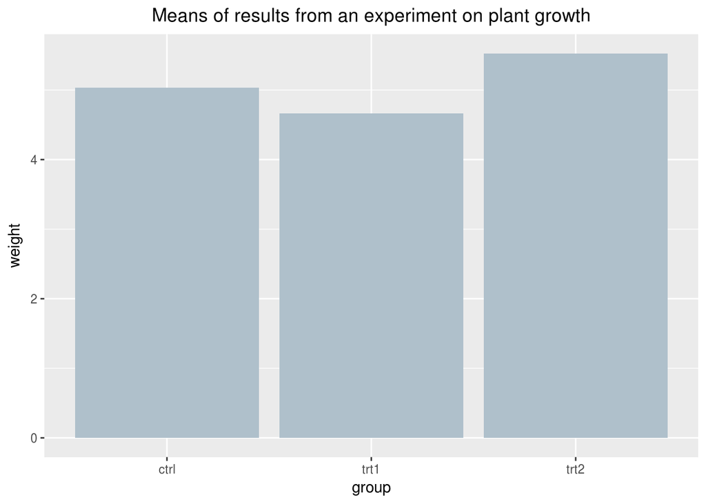

```r
## oszlopdiagram ggplot2-vel
# bar graph-ot készítünk: geom_bar
# értéket ábrázolunk: stat = "identity"
ggplot(data = pg_mean, aes(x = group, y = weight)) +
  geom_bar(stat = "identity", fill = "#AFC0CB") +
  ggtitle("Means of results from an experiment on plant growth") +
  theme(plot.title = element_text(hjust = 0.5))
```

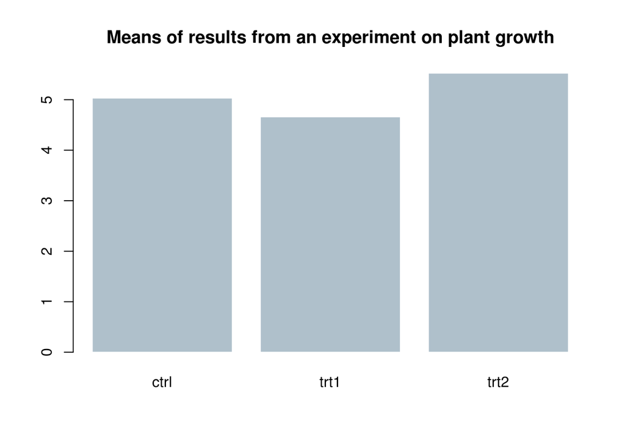

```r
## base oszlopdiagram
# bar graph-ot készítünk: barplot függvény
barplot(pg_mean$weight, names.arg = pg_mean$group,
        col = "#AFC0CB", border = FALSE,
        main = "Means of results from an experiment on plant growth")
```

### Egyszerű oszlopdiagramok - gyakoriság ábrázolása

```r
### Egyszerű oszlopdiagram - gyakoriság ábrázolása

# diamonds dataset: Prices of 50,000 round cut diamonds
head(diamonds)
```

```
## Source: local data frame [6 x 10]
##
##   carat       cut  color clarity depth table price     x     y     z
##   <dbl>    <fctr> <fctr>  <fctr> <dbl> <dbl> <int> <dbl> <dbl> <dbl>
## 1  0.23     Ideal      E     SI2  61.5    55   326  3.95  3.98  2.43
## 2  0.21   Premium      E     SI1  59.8    61   326  3.89  3.84  2.31
## 3  0.23      Good      E     VS1  56.9    65   327  4.05  4.07  2.31
## 4  0.29   Premium      I     VS2  62.4    58   334  4.20  4.23  2.63
## 5  0.31      Good      J     SI2  63.3    58   335  4.34  4.35  2.75
## 6  0.24 Very Good      J    VVS2  62.8    57   336  3.94  3.96  2.48
```

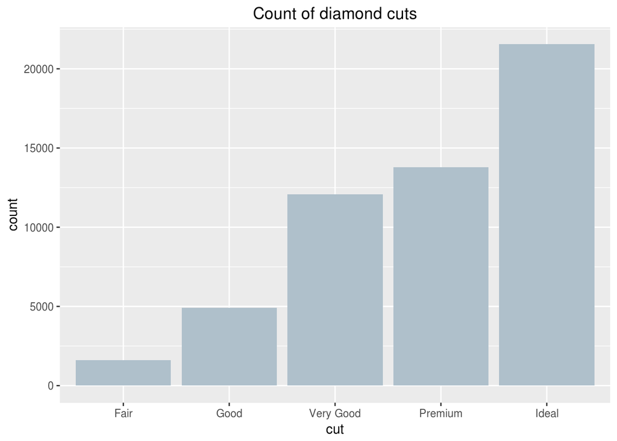

```r
## ggplot2
# gyakoriságot ábrázolunk: stat = "count"
ggplot(data = diamonds, aes(x = cut)) +
  geom_bar(stat = "count", fill = "#AFC0CB") +
  ggtitle("Count of diamond cuts") +
  theme(plot.title = element_text(hjust = 0.5))
```

```r
## base
# adat átalakítása
diamond_cuts <- table(diamonds$cut)
diamond_cuts
```

```
##
##      Fair      Good Very Good   Premium     Ideal
##      1610      4906     12082     13791     21551
```

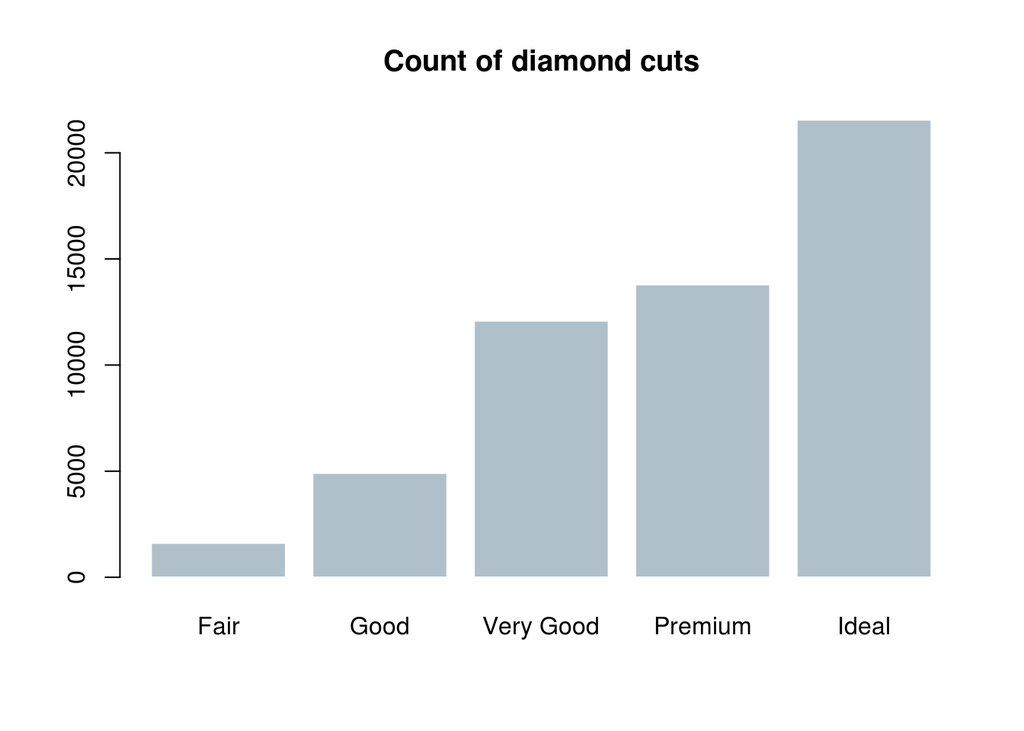

```r
barplot(diamond_cuts, col = "#AFC0CB", border = FALSE,
        main = "Count of diamond cuts")
```

### Csoportosított oszlopdiagramok (Stacked bar graphs)

- amikor egy második kategória szerint csoportosítani szeretnénk az oszlopdiagramokat

```r
### Csoportosított oszlopdiagram
# cabbage_exp dataset
cabbage_exp
```

```
##   Cultivar Date Weight        sd  n         se
## 1      c39  d16   3.18 0.9566144 10 0.30250803
## 2      c39  d20   2.80 0.2788867 10 0.08819171
## 3      c39  d21   2.74 0.9834181 10 0.31098410
## 4      c52  d16   2.26 0.4452215 10 0.14079141
## 5      c52  d20   3.11 0.7908505 10 0.25008887
## 6      c52  d21   1.47 0.2110819 10 0.06674995
```

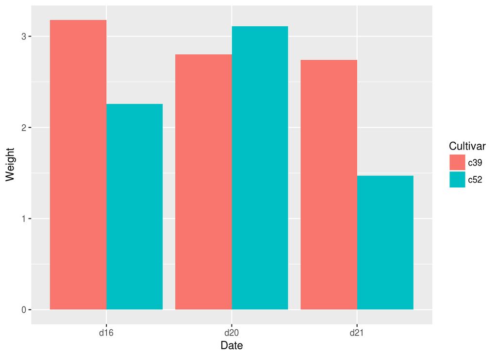

```r
## ggplot2
# csoportosítás egymás melletti oszlopokba
ggplot(cabbage_exp, aes(x = Date, y = Weight, fill = Cultivar)) +
  geom_bar(stat = "identity", position = position_dodge())
```

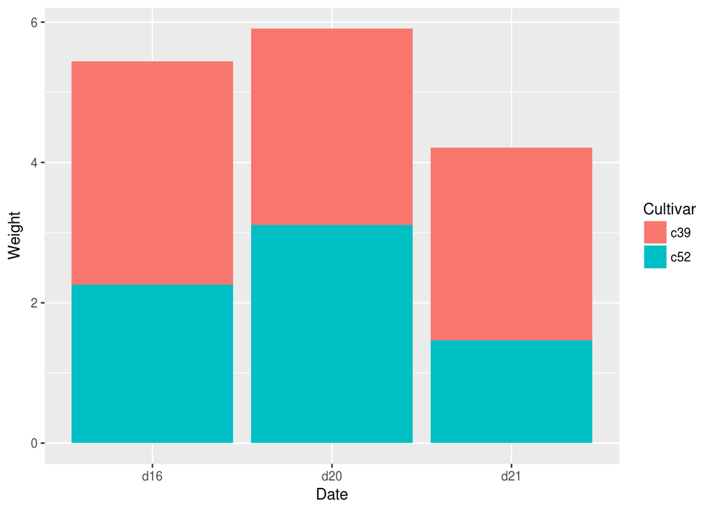

```r
# csoportosítás egy oszlop több felé osztásával
ggplot(cabbage_exp, aes(x = Date, y = Weight, fill = Cultivar)) +
  geom_bar(stat = "identity", position = position_stack())
```

```r
## base
# adatok átalakítása
cabbage_mat <- matrix(cabbage_exp$Weight, nrow = 2, byrow=TRUE,
                      dimnames = list(c("c39", "c52"), c("d16", "d20", "d21")))
cabbage_mat
```

```
##      d16  d20  d21
## c39 3.18 2.80 2.74
## c52 2.26 3.11 1.47
```

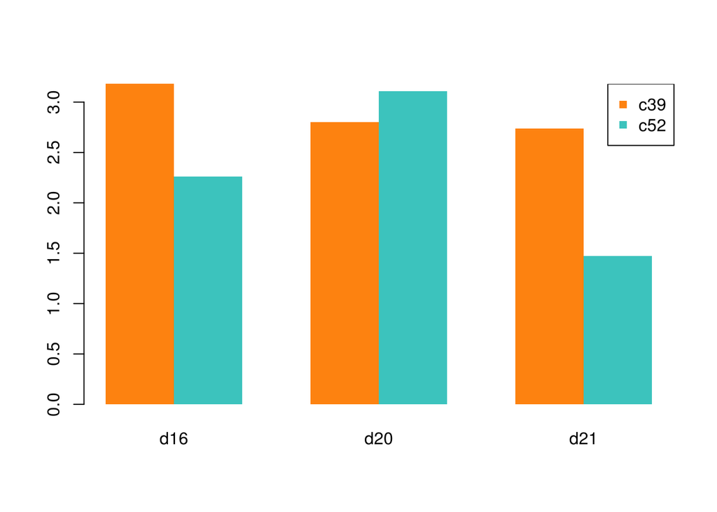

```r
# oszlopszínek
mf_col <- c("#FD8210", "#3CC3BD")
# csoportosítás egymás melletti oszlopokba
barplot(cabbage_mat, beside = TRUE, border = NA, col = mf_col)
# legend hozzáadása
legend("topright", row.names(cabbage_mat), pch = 15, col = mf_col)
```

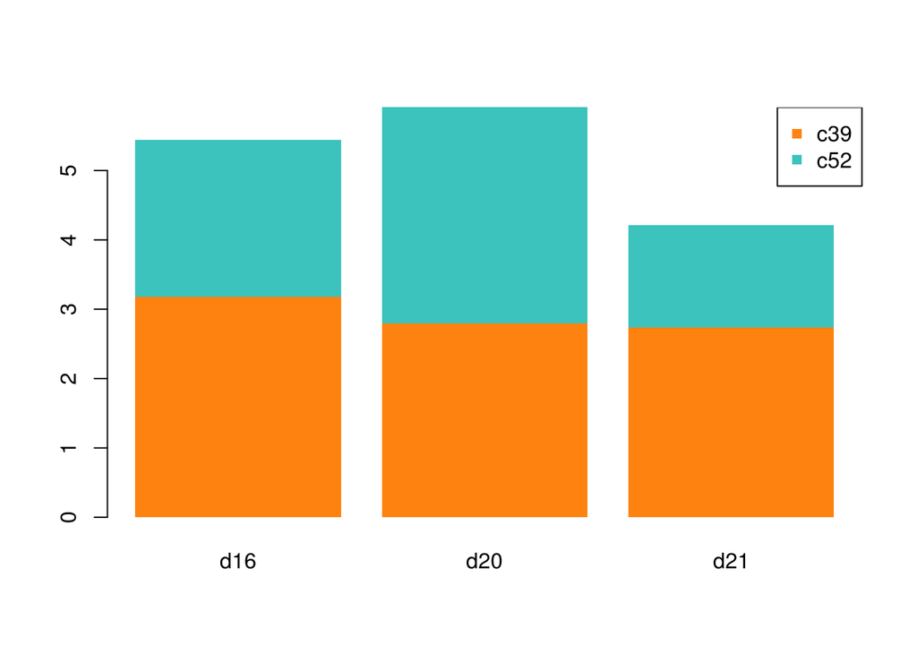

```r
# csoportosítás egy oszlop több felé osztásával
barplot(cabbage_mat, border = NA, col = mf_col)
legend("topright", row.names(cabbage_mat), pch = 15, col = mf_col)
```

## Vonaldiagramok (Line Graphs)

- ha azt szeretnénk ábrázolni, hogy egy folytonos változó (y-tengely) hogyan alakul egy másik folytonos változó függvényében (x-tengely)
- az x-tengelyen gyakran az idő van, tehát az idősorok ábrázolása is ebbe a kategóriába tartozik, de lehet más folytonos változó is, pl. egy kísérlet során adagolt gyógyszer mennyisége
- adott esetben ordinális mérési szintű változókat is ábrázolhatunk ilyen módon, de nominálisakat nem

### Egyszerű vonaldiagramok

```r
#---Vonaldiagramok (Line Graphs)------------------------------------------------
### Egyszerű vonaldiagramok

# BOD dataset: Biochemical Oxygen Demand
BOD
```

```
##   Time demand
## 1    1    8.3
## 2    2   10.3
## 3    3   19.0
## 4    4   16.0
## 5    5   15.6
## 6    7   19.8
```

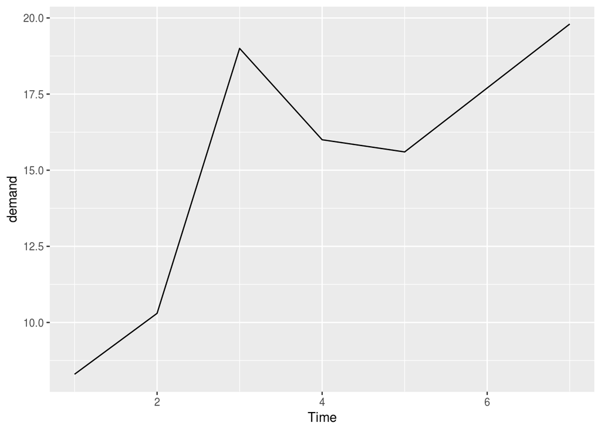

```r
## ggplot2
# line graph-ot csinálunk: geom_line
# time numerikus adat
ggplot(BOD, aes(x = Time, y = demand)) + geom_line()
```

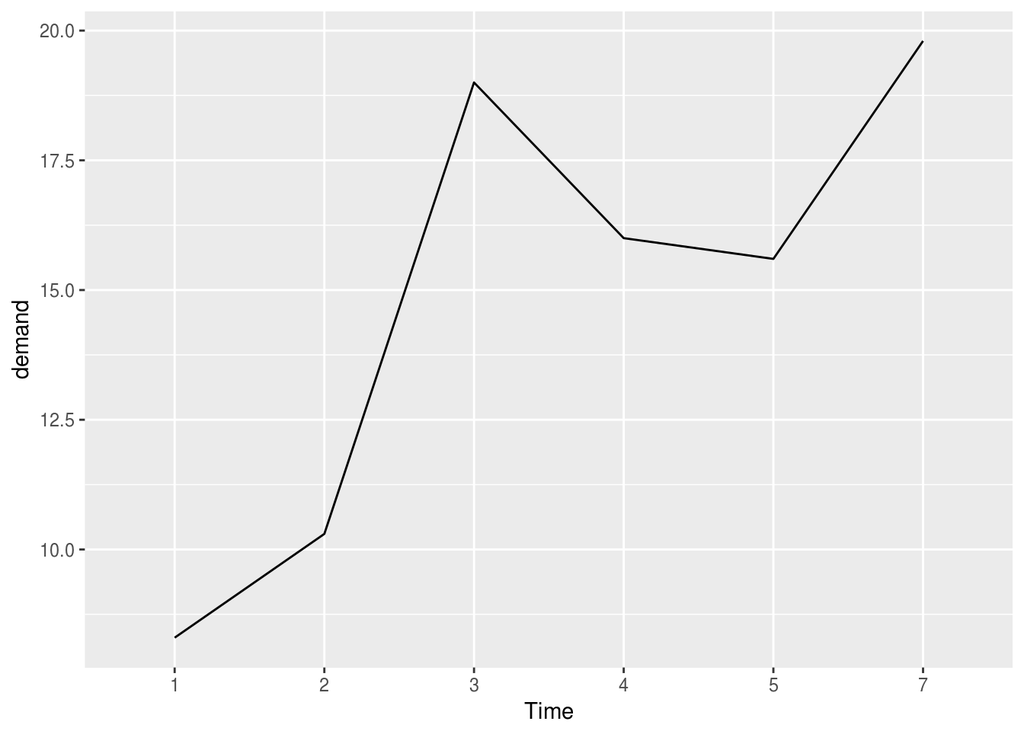

```r
# ha a time faktor
BOD1 <- BOD
BOD1$Time <- factor(BOD1$Time)
# group = 1 használata, hogy tudja, hogy összetartoznka a pontok
ggplot(BOD1, aes(x = Time, y = demand, group = 1)) + geom_line()
```

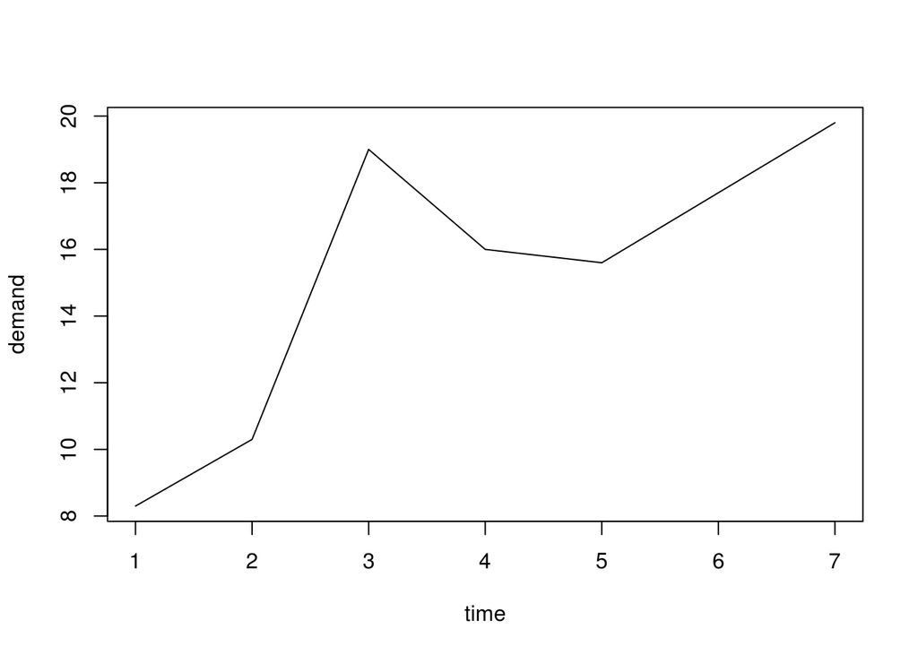

```r
## base
# line graph-ot csinálunk: plot függvény type = "l" argumentummal
plot(BOD$Time, BOD$demand, type = "l", xlab = "time", ylab = "demand")
```

```r
# y-tengely most nem időt jelöl, hanem más folytonos változó
# data frame definiálása
dat1 <- data.frame(
  time = factor(c("Lunch", "Dinner"), levels = c("Lunch", "Dinner")),
  total_bill = c(14.89, 17.23)
)
dat1
```

```
##     time total_bill
## 1  Lunch      14.89
## 2 Dinner      17.23
```

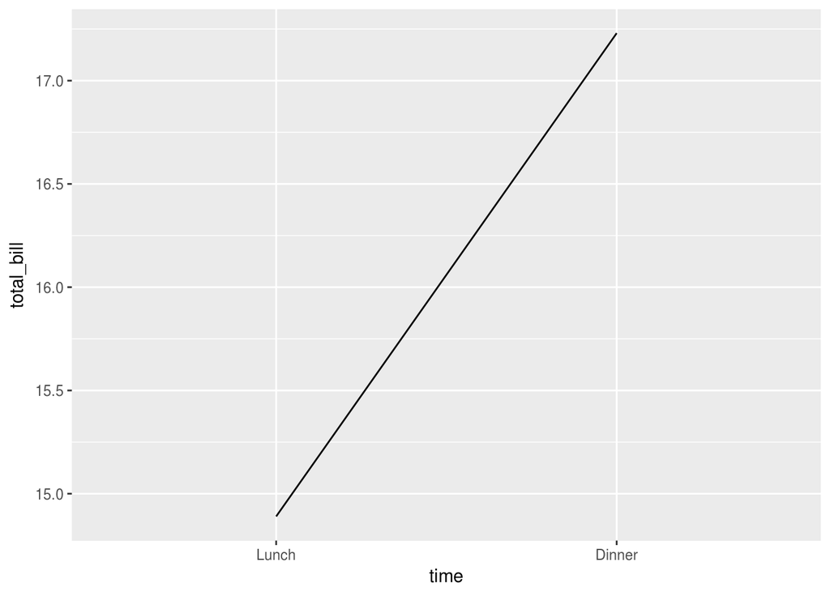

```r
## ggplot2
# árak ábrázolása az étkezések függvényében
ggplot(data = dat1, aes(x = time, y = total_bill, group = 1)) + geom_line()
```

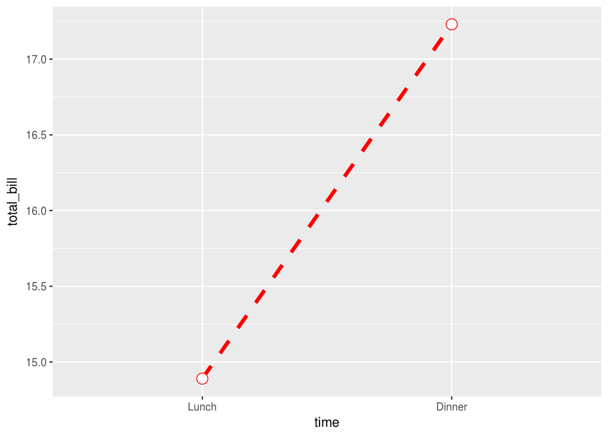

```r
# vonal egyéb opciókkal (szín, típus, méret)
# pontok hozzáadása a geom_point-tal
ggplot(data = dat1, aes(x = time, y = total_bill, group = 1)) +
    geom_line(colour = "red", linetype = "dashed", size = 1.5) +
    geom_point(colour = "red", size = 4, shape = 21, fill = "white")
```

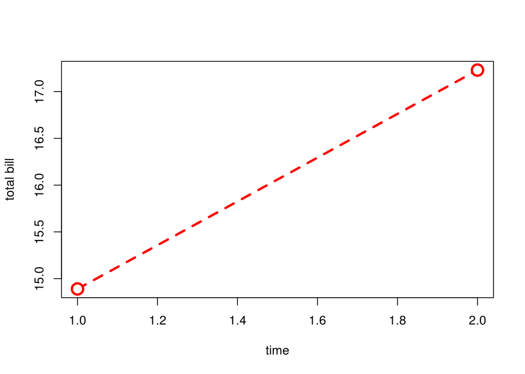

```r
## base
plot(c(1, 2), dat1$total_bill, type = "l", xlab = "time", ylab = "total bill", lty = 2,
     lwd = 3, col = "red")
points(c(1, 2), dat1$total_bill, pch = 21, col = "red", cex = 2, bg = "white",
       lwd = 3)
```

### Többszörös vonaldiagramok

```r
### Többszörös vonaldiagramok

# data frame definiálása
dat2 <- data.frame(
  sex = factor(c("Female", "Female", "Male", "Male")),
  time = factor(c("Lunch", "Dinner", "Lunch", "Dinner"),
  levels = c("Lunch", "Dinner")),
  total_bill = c(13.53, 16.81, 16.24, 17.42))
dat2
```

```
##      sex   time total_bill
## 1 Female  Lunch      13.53
## 2 Female Dinner      16.81
## 3   Male  Lunch      16.24
## 4   Male Dinner      17.42
```

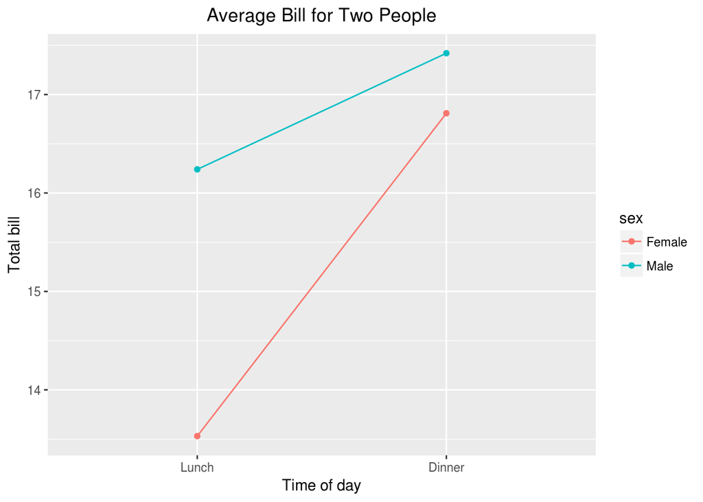

```r
## ggplot2
# a nem szerint szeretnénk több vonalat: group = sex
# a színezést is a nem szerint szeretnénk: colour = sex
ggplot(data = dat2, aes(x = time, y = total_bill, group = sex, colour = sex)) +
  geom_line() + geom_point() + ggtitle("Average Bill for Two People") +
  xlab("Time of day") + ylab("Total bill") +
  theme(plot.title = element_text(hjust = 0.5))
```

```r
## base
# adat átalakítása
dat2_mat <- matrix(dat2$total_bill, nrow = 2, byrow=TRUE,
                   dimnames = list(c("Female", "Male"), c("Lunch", "Dinner")))
dat2_mat
```

```
##        Lunch Dinner
## Female 13.53  16.81
## Male   16.24  17.42
```

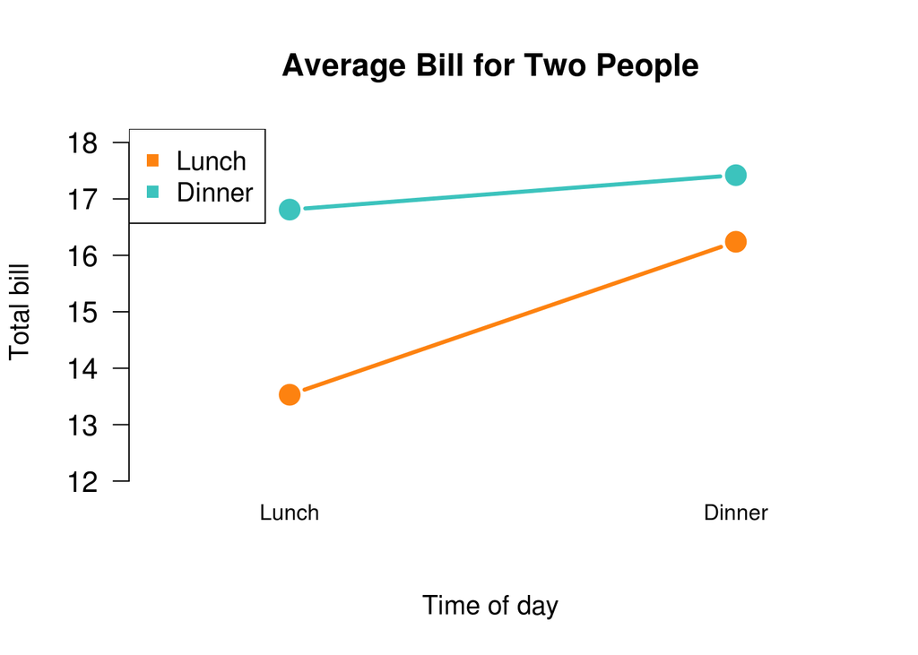

```r
par(cex = 1.2, cex.axis = 1.1)
matplot(dat2_mat, type = "b", lty = 1, pch = 19, col = mf_col, cex = 1.5,
        lwd = 3, las = 1, bty = "n", xaxt = "n", xlim = c(0.7, 2.2),
        ylim = c(12,18), xlab = "Time of day", ylab = "Total bill",
        main = "Average Bill for Two People")
mtext("Lunch", side = 1, at = 1)
mtext("Dinner", side = 1, at = 2)
legend("topleft", c("Lunch", "Dinner"), pch = 15, col = mf_col)
```

## Pontfelhődiagramok/szórásdiagramok (Scatter plots)

- két folytonos változó kapcsolatát ábrázoljuk vele
- minden megfigyelés egy külön pont a ploton
- gyakran illesztenek a pontfelhőre vonalakat, görbéket is vmilyen statisztikai modell szerint

### Egyszerű szórásdiagramok

```r
#---Pontfelhődiagramok/szórásdiagramok (Scatter plots)--------------------------
### Egyszerű szórásdiagramok

set.seed(955)
# data frame definiálása
dat3 <- data.frame(cond = rep(c("A", "B"), each = 10),
                   xvar = 1:20 + rnorm(20, sd = 3),
                   yvar = 1:20 + rnorm(20, sd = 3))
head(dat3)
```

```
##   cond      xvar         yvar
## 1    A -4.252354  3.473157275
## 2    A  1.702318  0.005939612
## 3    A  4.323054 -0.094252427
## 4    A  1.780628  2.072808278
## 5    A 11.537348  1.215440358
## 6    A  6.672130  3.608111411
```

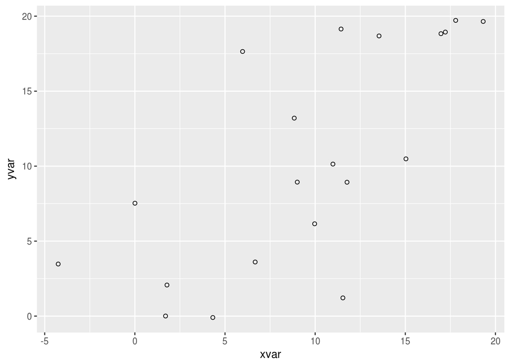

```r
## ggplot2
# scatter plot: geom_point
# shape = 1 üres karika
ggplot(dat3, aes(x = xvar, y = yvar)) + geom_point(shape = 1)
```

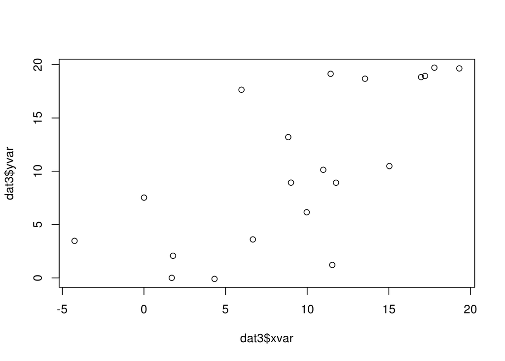

```r
## base
# scatter plotot csinálunk: plot függvény defaultja
plot(dat3$xvar, dat3$yvar)
```

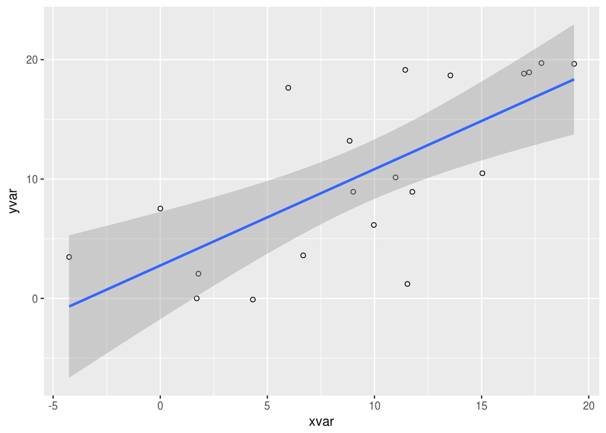

```r
## ggplot2
# lineáris regresszió illesztése 95%-os konfidencia intervallummal
ggplot(dat3, aes(x = xvar, y = yvar)) + geom_point(shape = 1) +
  geom_smooth(method = lm)
```

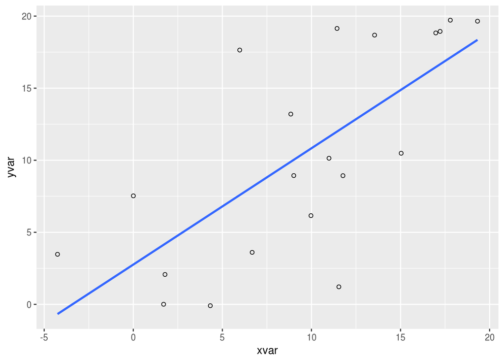

```r
# konfidencia intervallum nélkül
ggplot(dat3, aes(x = xvar, y = yvar)) + geom_point(shape = 1) +
  geom_smooth(method = lm, se = FALSE)
```

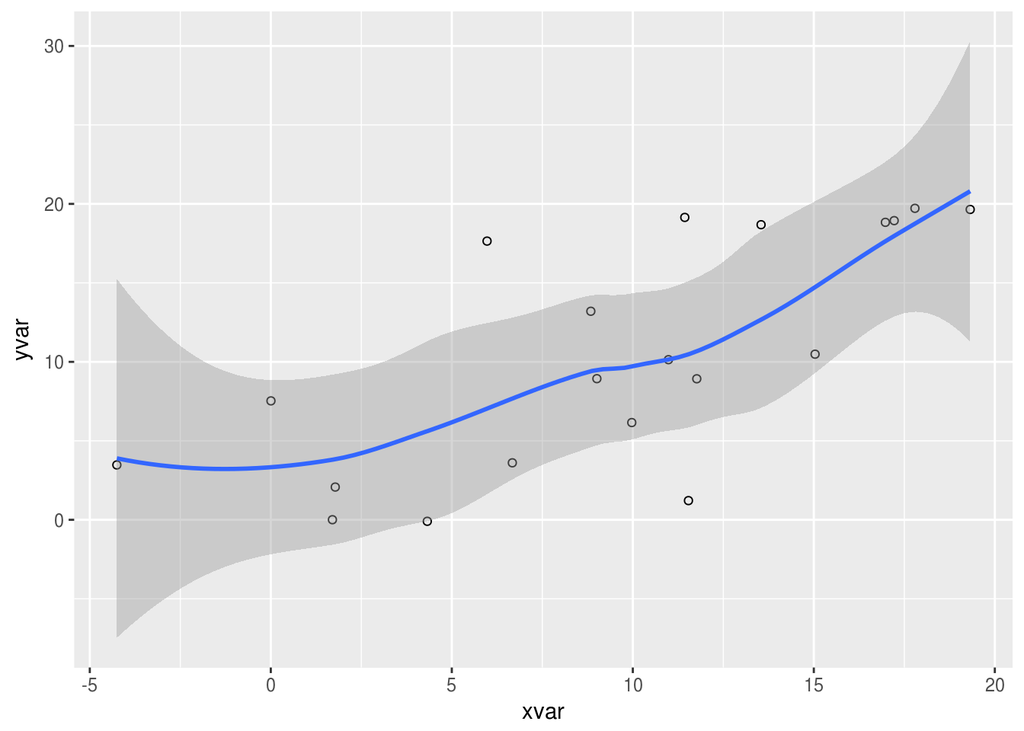

```r
# loess görbe
ggplot(dat3, aes(x = xvar, y = yvar)) + geom_point(shape = 1) +
  geom_smooth(method = loess)
```

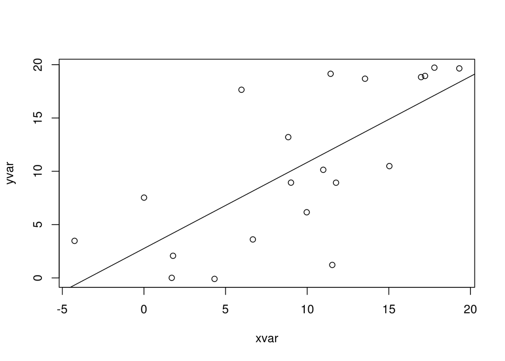

```r
## base
# ugyanaz, mint előbb, csak formulával
plot(yvar ~ xvar, dat3)
fitline <- lm(dat3$yvar ~ dat3$xvar)
abline(fitline)
```

### Csoportra bontott szórásdiagramok

- amikor egy kategória szerint el szeretnék különíteni a pontfelhőt

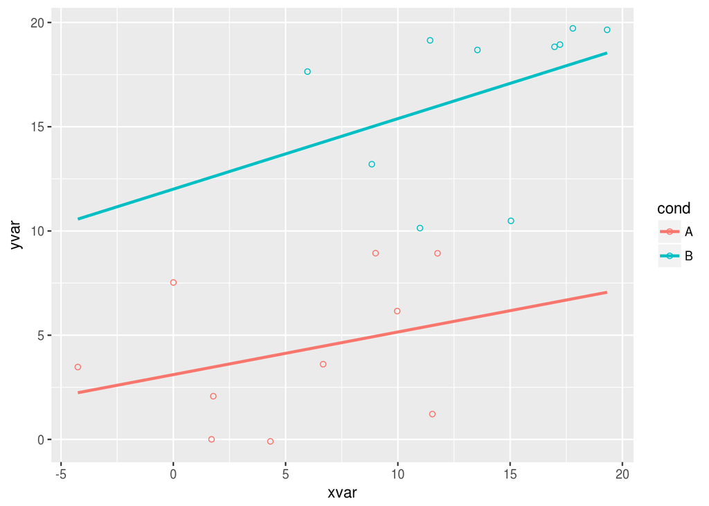

```r
### Csoportra bontott szórásdiagramok

## ggplot2
# kondíció szerint színekre szétbontva
# lineáris regressziós vonallal
ggplot(dat3, aes(x = xvar, y = yvar, color = cond)) +
  geom_point(shape = 1) +
  geom_smooth(method = lm, se = FALSE, fullrange = TRUE)
```

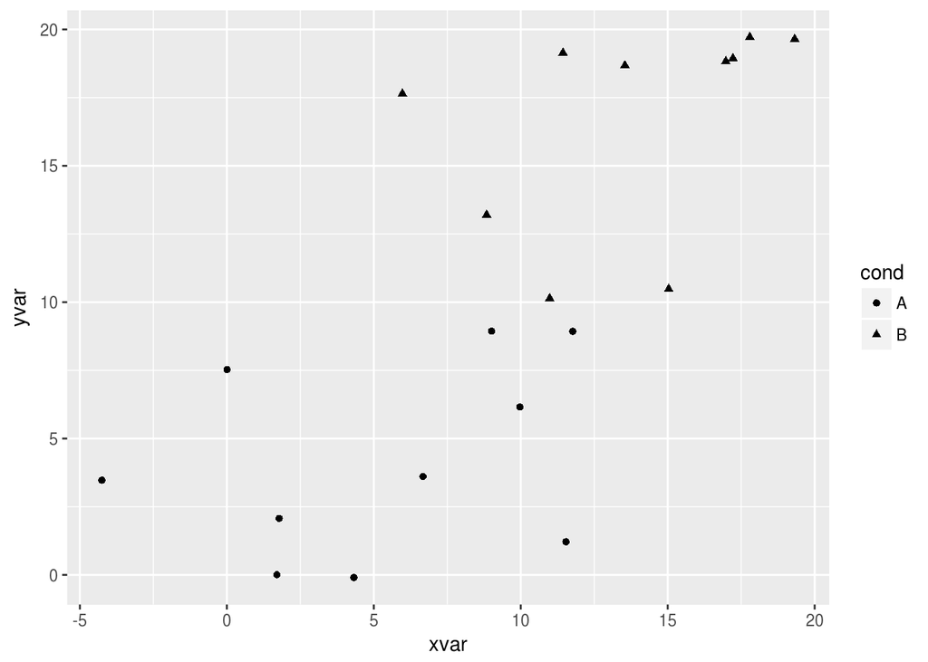

```r
# kondíció szerint formákra szétbontva
ggplot(dat3, aes(x = xvar, y = yvar, shape = cond)) +
  geom_point()
```

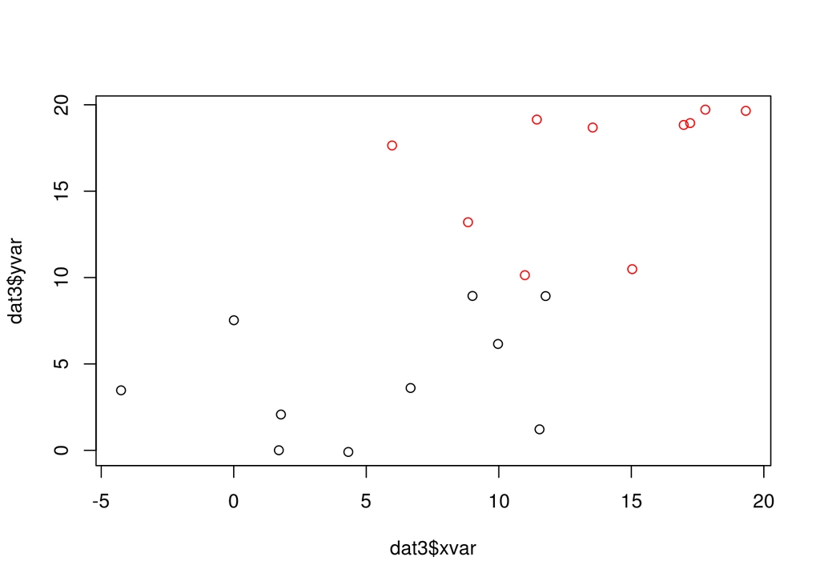

```r
## base
plot(dat3$xvar, dat3$yvar, col = dat3$cond)
```

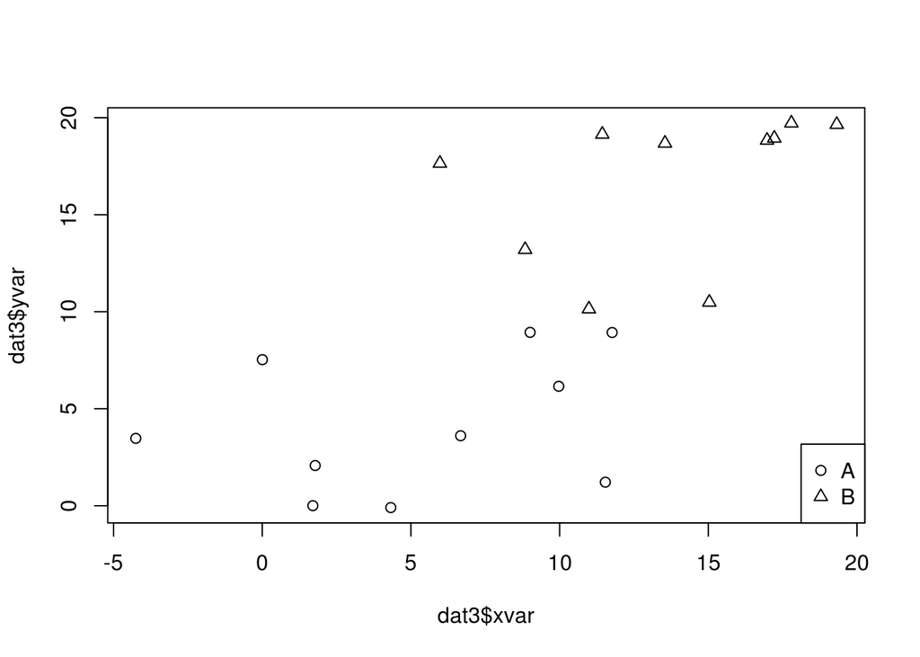

```r
plot(dat3$xvar, dat3$yvar, pch = unclass(dat3$cond))
legend("bottomright", legend = levels(dat3$cond), pch = c(1:3))
```

### Annotált szórásdiagramok

- előfordul, hogy a pontfelhő pontjait feliratozni szeretnénk a kategóriája vagy neve stb. alapján

```r
### Annotált szórásdiagramok
# countries dataset: Health and economic data about countries around the world
countries_sub <- subset(countries, Year == 2009 & healthexp > 2000)
head(countries_sub)
```

```
##           Name Code Year      GDP laborrate healthexp infmortality
## 254    Andorra  AND 2009       NA        NA  3089.636          3.1
## 560  Australia  AUS 2009 42130.82      65.2  3867.429          4.2
## 611    Austria  AUT 2009 45555.43      60.4  5037.311          3.6
## 968    Belgium  BEL 2009 43640.20      53.5  5104.019          3.6
## 1733    Canada  CAN 2009 39599.04      67.8  4379.761          5.2
## 2702   Denmark  DNK 2009 55933.35      65.4  6272.729          3.4
```

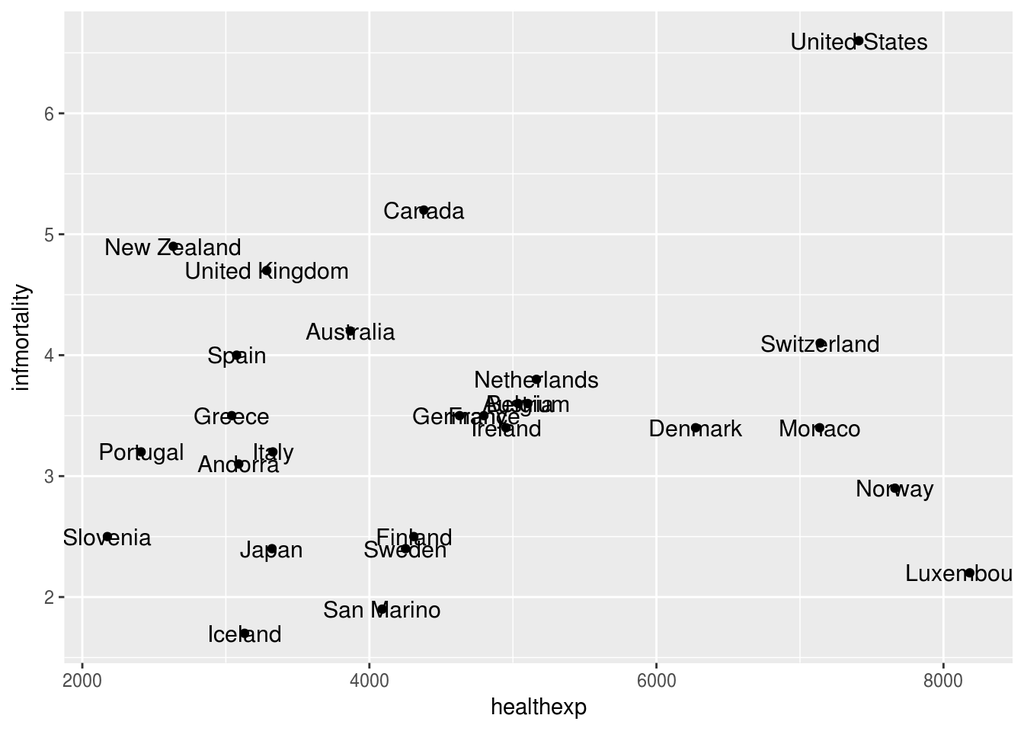

```r
## ggplot2
# geom_text-tel annotálunk
ggplot(countries_sub, aes(x = healthexp, y = infmortality)) +
  geom_point() +
  geom_text(aes(label = Name), size = 4)
```

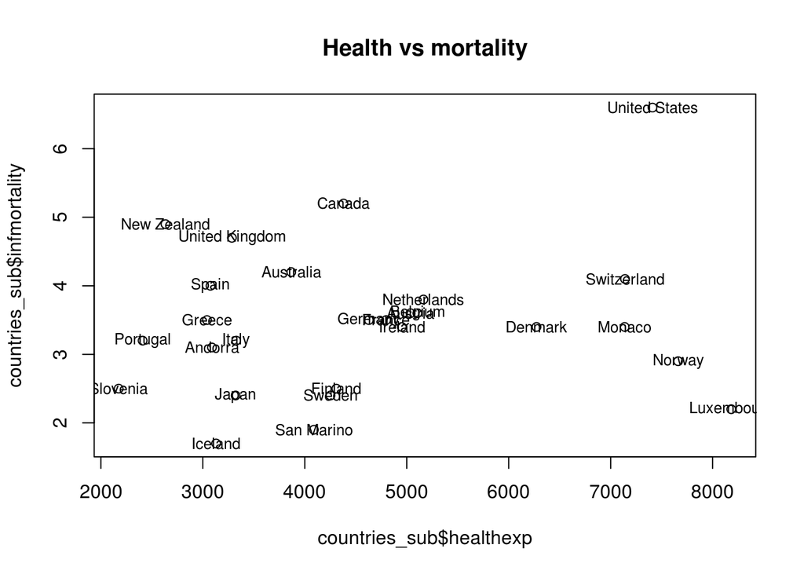

```r
## base
# text függvénnyel annotálunk
plot(countries_sub$healthexp, countries_sub$infmortality,
     main = "Health vs mortality")
text(countries_sub$healthexp, countries_sub$infmortality,
     labels = as.character(countries_sub$Name), cex = 0.8)
```

### Szórásdiagram mátrix

- több változó összehasonlítása egymással

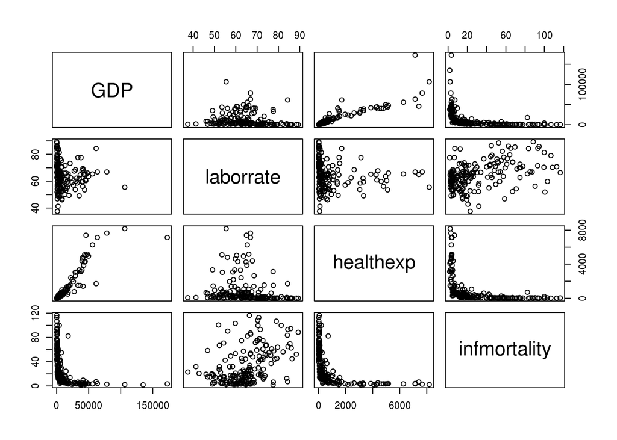

```r
### Szórásdiagram mátrix
source("src/prog1_lesson06_part01_Grafikus_abrazolasok_functions.R")
c2009 <- subset(countries, Year == 2009,
                select = c(Name, GDP, laborrate, healthexp, infmortality))

pairs(c2009[, 2:5])
```

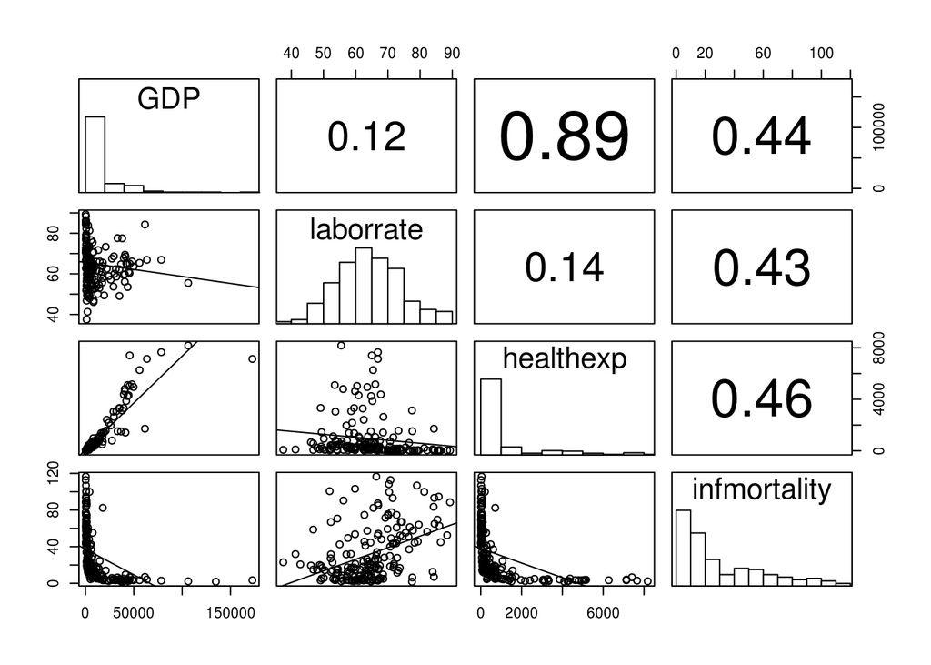

```r
pairs(c2009[, 2:5], upper.panel = panel.cor,
      diag.panel = panel.hist, lower.panel = panel.lm)
```